# Lecture 7: Exploratory data analysis

2016/10/26

## RMD_example 7.1: Read the Gene expression microarray data (samplexprs.csv)

```r
# Get the file url
fileurl <- "http://ghuang.stat.nctu.edu.tw/course/statmethods16/files/data/samplexprs.csv"

# Import the csv file into R
#   note: stringsAsFactors=TRUE will screw up conversion to numeric!
samplexprs <- read.csv(fileurl, header=TRUE, stringsAsFactors=FALSE)

dim(samplexprs)
```

```
## [1]   78 4746
```

```r
head(samplexprs[,1:10])
```

```
##     id age metastases followup ERp J00129 Contig29982_RC Contig42854
## 1 FG80  52          0     7.35 100 -0.795         -0.387       0.199
## 2 SF58  50          1     1.15   0 -0.509          0.459      -0.257
## 3 DE72  54          0    12.12 100 -0.961         -0.631       0.037
## 4 DE65  40          0     6.25   0 -0.749          0.699      -0.346
## 5 HG87  53          0     5.18   0 -0.426         -0.406      -0.355
## 6 HG88  37          1     1.09 100 -0.566         -0.596      -0.352
##   Contig42014_RC Contig27915_RC
## 1         -0.247          0.176
## 2         -0.065          0.129
## 3         -0.153          0.144
## 4          0.032          0.300
## 5          0.429         -0.036
## 6         -0.336          0.037
```

## RMD_example 7.2: Stem-and-leaf plot

```r
stem(samplexprs$age)
```

```
##
##   The decimal point is 1 digit(s) to the right of the |
##
##   2 | 88
##   3 | 00234
##   3 | 677788889999
##   4 | 00111111112333444
##   4 | 55555666678888888999
##   5 | 0012222222333444444444
```

```r
stem(samplexprs$J0012)
```

```
##
##   The decimal point is at the |
##
##   -2 | 0
##   -1 |
##   -1 | 321000
##   -0 | 9999998888888888777777776666666666666665555555555555
##   -0 | 4444444433221
##    0 | 01
##    0 | 689
##    1 | 2
```

## RMD_example 7.3: q-q plot

For q-q plot, we can first compute the percentiles for our list of data (ages/J0012) and for the normal distribution, and then compare them.

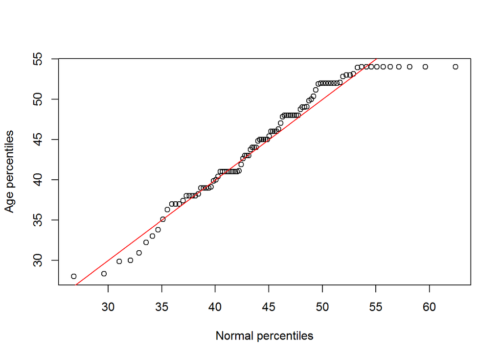

```r
library(rafalib)

# plot for age
x <- samplexprs$age
ps <- ( seq(0,99) + 0.5 )/100
qs <- quantile(x, ps)
normalqs <- qnorm(ps, mean(x), popsd(x))
plot(normalqs,qs,xlab="Normal percentiles",ylab="Age percentiles")
abline(0,1, col="red") ##identity line
```

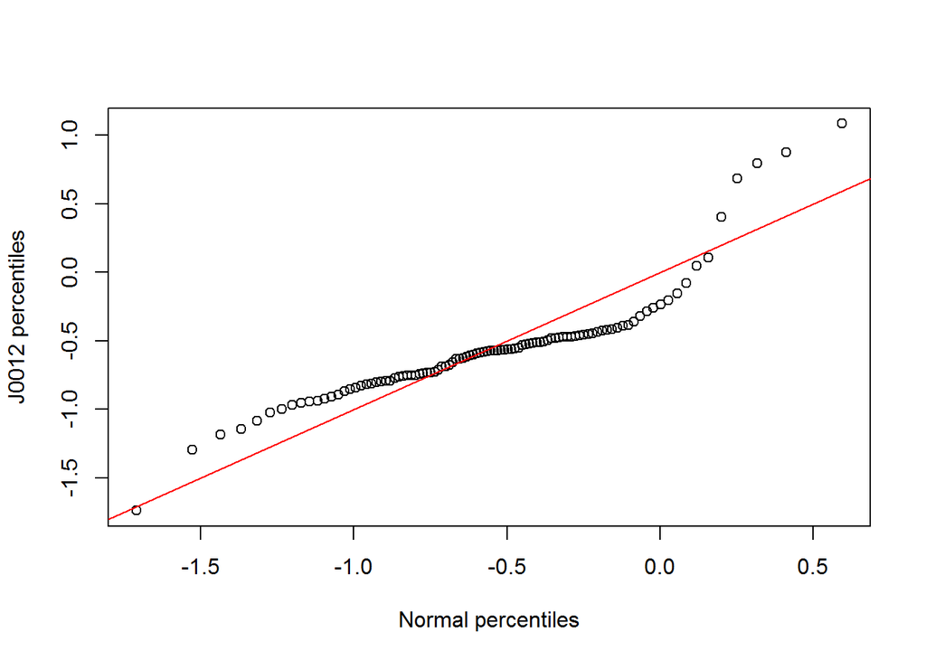

```r
# plot for J0012
y <- samplexprs$J0012
ps <- ( seq(0,99) + 0.5 )/100
qs <- quantile(y, ps)
normalqs <- qnorm(ps, mean(y), popsd(y))
plot(normalqs,qs,xlab="Normal percentiles",ylab="J0012 percentiles")
abline(0,1, col="red") ##identity line
```

We can also see the plot with the existing function `qqnorm`.

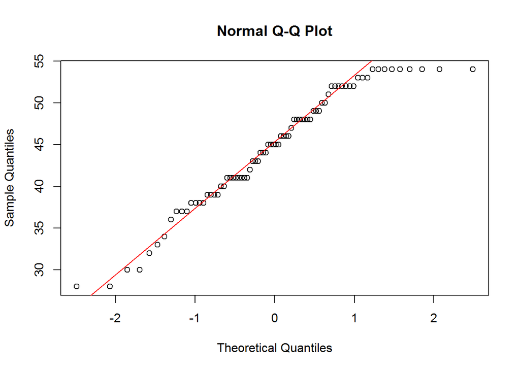

```r
qqnorm(x); qqline(x, col="red")
```

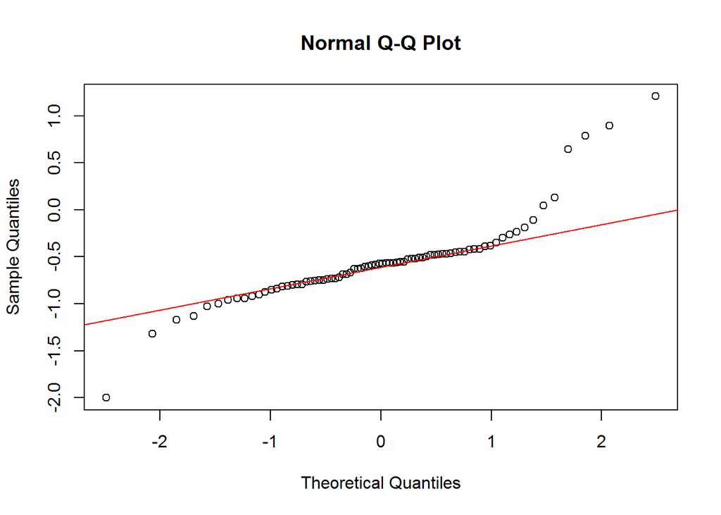

```r
qqnorm(y); qqline(y, col="red")
```

Notice that the `qqnorm` function plots against a **standard normal** distribution. This is why the line has slope `popsd(x)` (or `popsd(y)`) and intercept `mean(x)` (or `mean(y)`).

In fact, we can run Monte Carlo simulations to see plots like this for data known to be normally distributed.

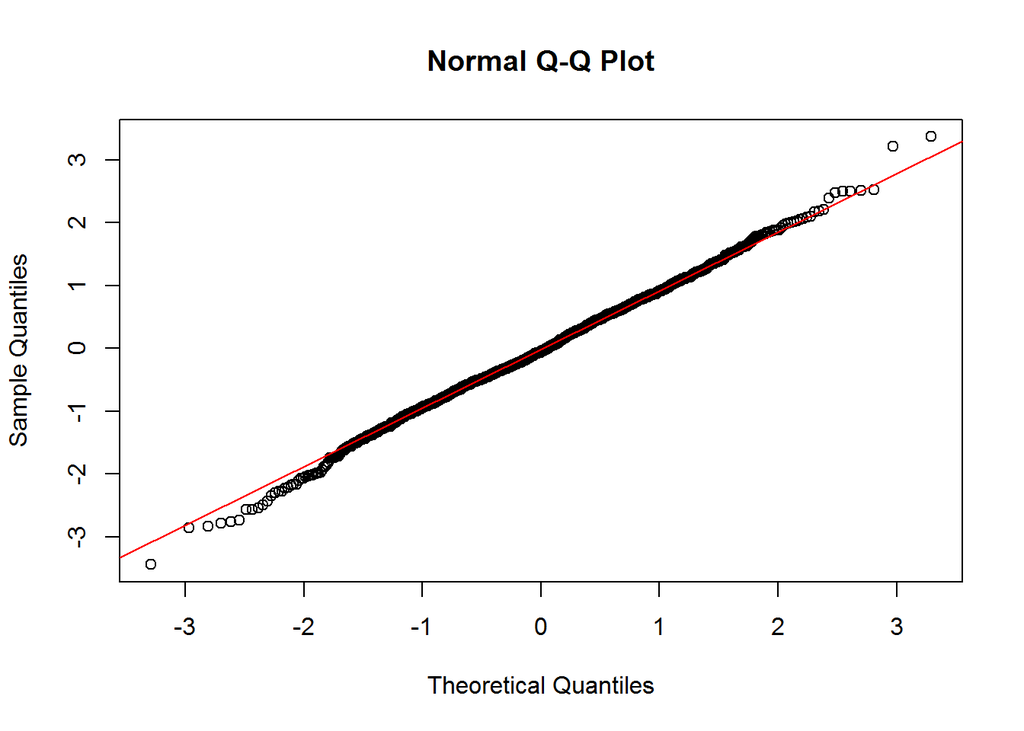

```r
n <-1000
x <- rnorm(n)
qqnorm(x)
qqline(x, col="red")
```

We can also get a sense for how non-normally distributed data will look in a qq-plot. Here we generate data from the t-distribution with different degrees of freedom. Notice that the smaller the degrees of freedom, the fatter the tails. We call these “fat tails” because if we plotted an empirical density or histogram, the density at the extremes would be higher than the theoretical curve. In the qq-plot, this can be seen in that the curve is lower than the identity line on the left side and higher on the right side. This means that there are more extreme values than predicted by the theoretical density plotted on the x-axis.

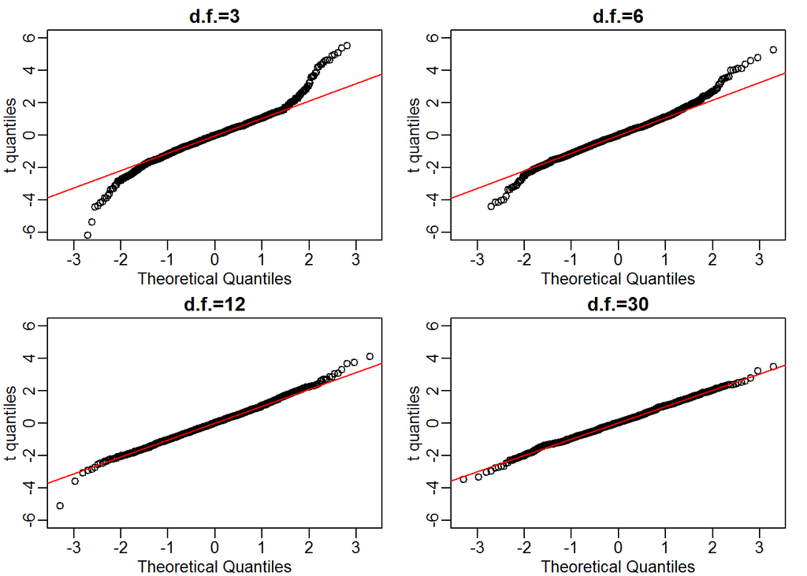

```r
dfs <- c(3,6,12,30)
mypar(2,2)
for(df in dfs){
  x <- rt(1000,df)
  qqnorm(x,ylab="t quantiles",main=paste0("d.f.=",df),ylim=c(-6,6))
  qqline(x, col="red")
}
```

## RMD_example 7.4: Histogram

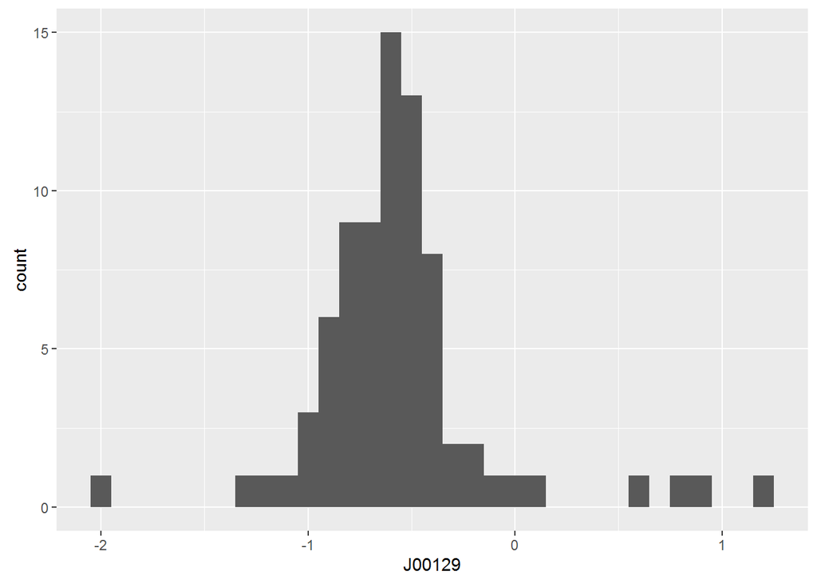

```r
# Install package "ggplot2" first, then load it into R
library(ggplot2)

# with qplot
qplot(J00129, data=samplexprs, geom="histogram", binwidth=0.1)
```

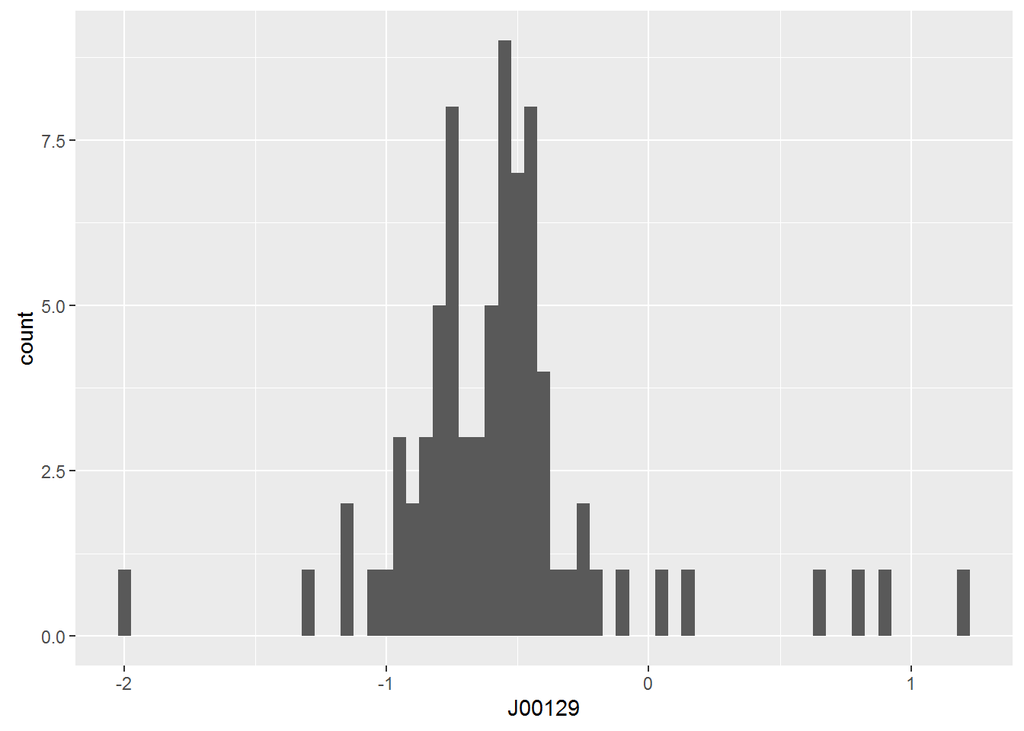

```r
qplot(J00129, data=samplexprs, geom="histogram", binwidth=0.05)
```

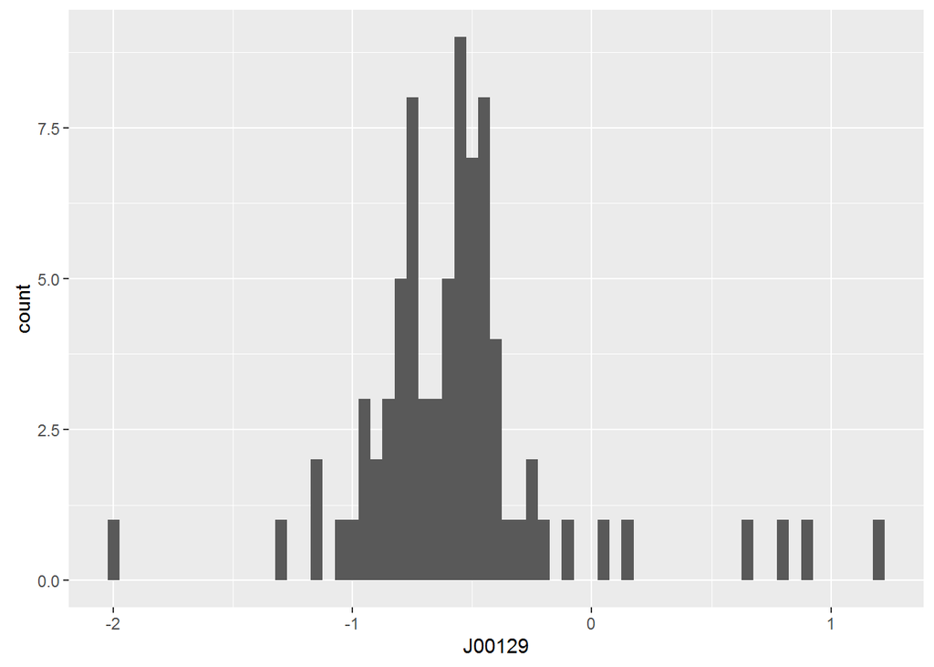

```r
# with ggplot
h <- ggplot(samplexprs, aes(x=J00129))
h + geom_histogram(binwidth=0.05)
```

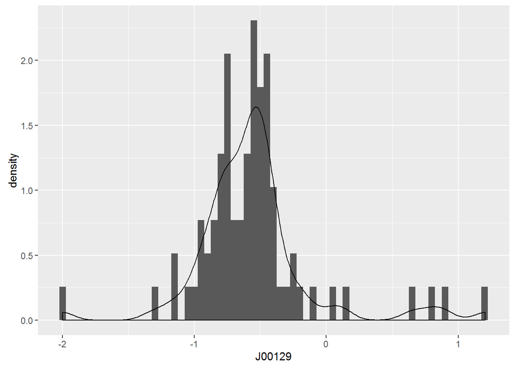

```r
#    display a smooth density estimate
h + geom_histogram(aes(y = ..density..), binwidth=0.05) + geom_density()
```

## RMD_example 7.5: Boxplot (=1)

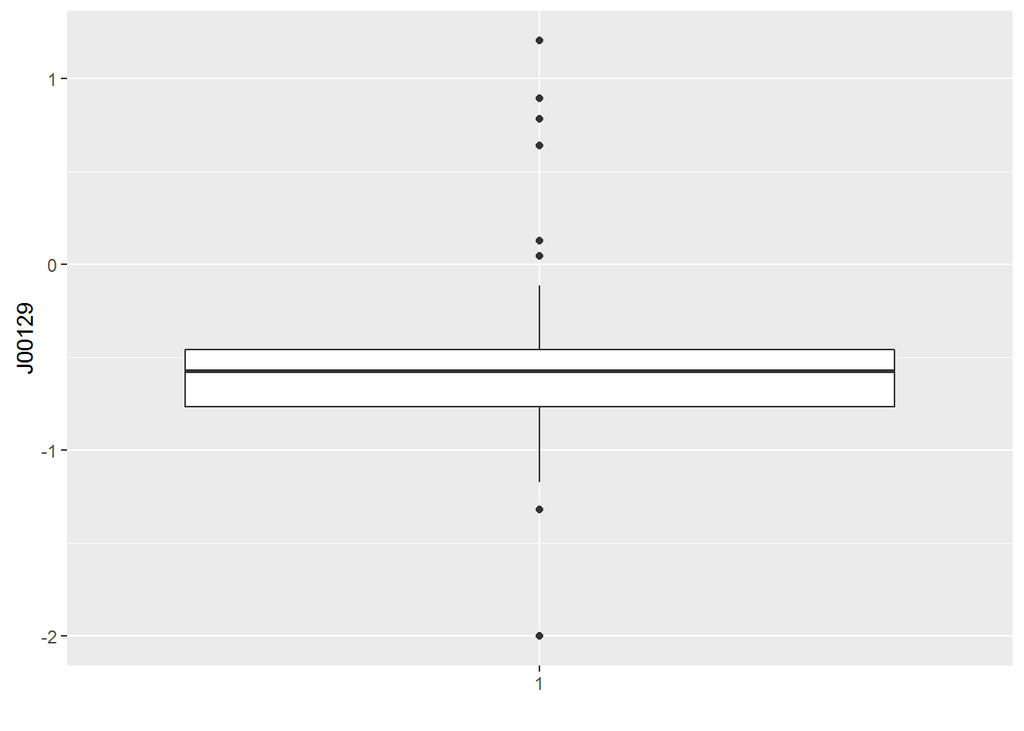

```r
qplot(x=factor(1), y=J00129, data=samplexprs, geom="boxplot", xlab="")
```

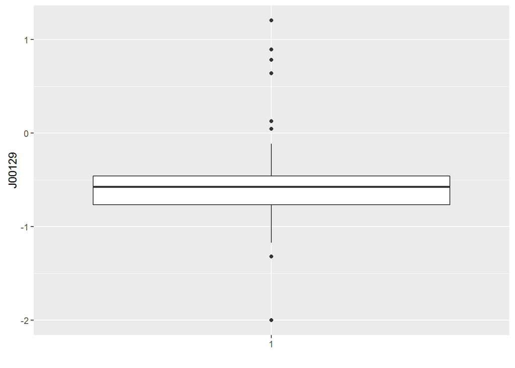

```r
b <- ggplot(samplexprs, aes(x=factor(1), y=J00129))
b + geom_boxplot() + labs(x="")
```

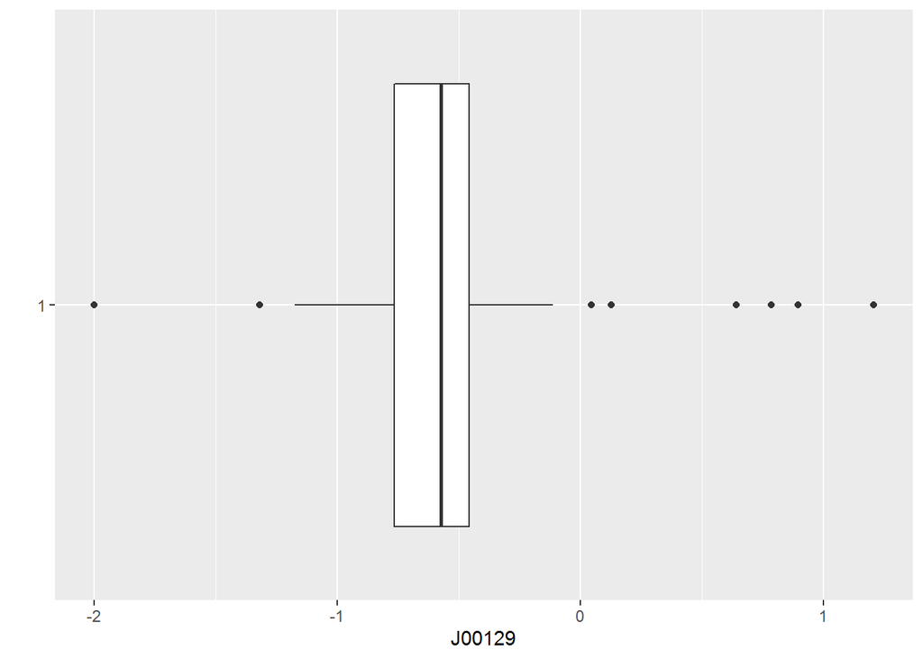

```r
b + geom_boxplot() + labs(x="") + coord_flip()
```

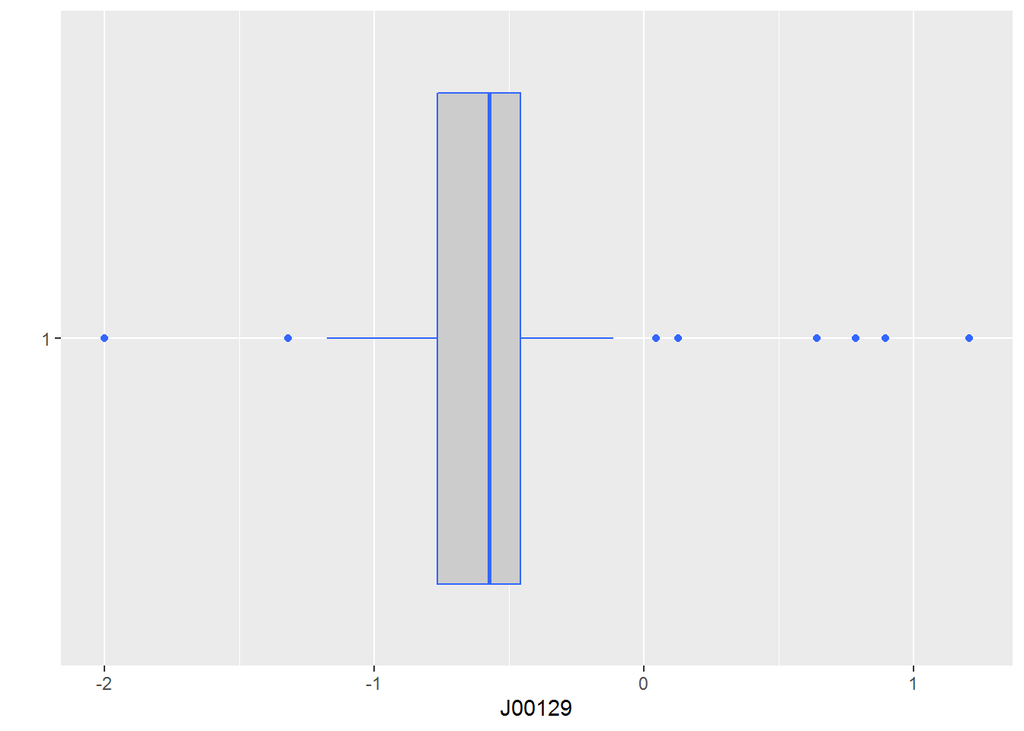

```r
b + geom_boxplot(fill="grey80", colour="#3366FF") + labs(x="") + coord_flip()
```

## RMD_example 7.6: Bar chart

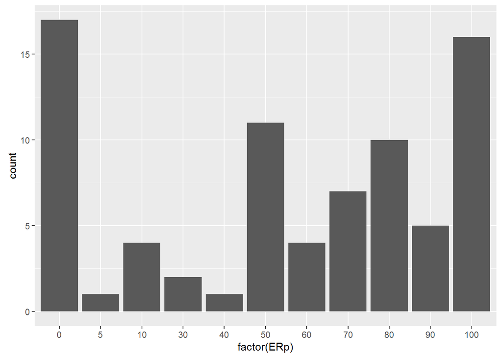

```r
ba <- ggplot(samplexprs, aes(x=factor(ERp)))
ba + geom_bar()
```

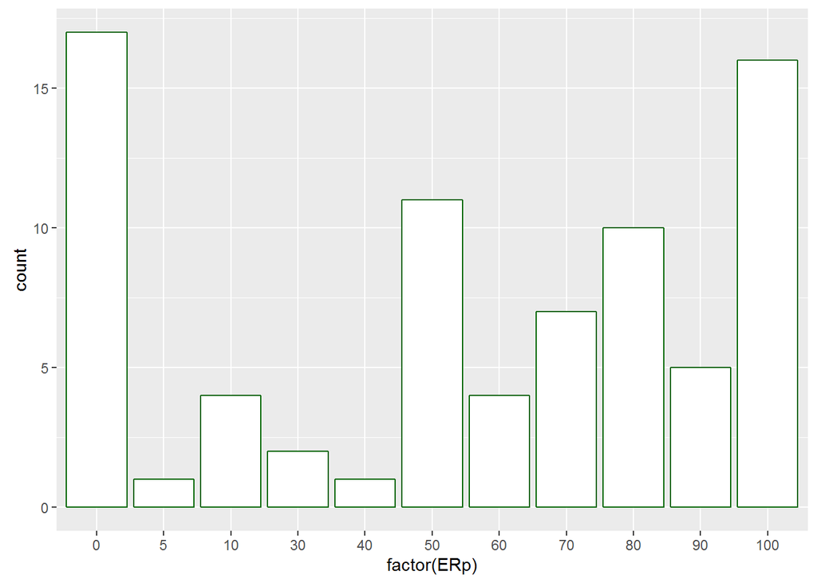

```r
ba + geom_bar(fill="white", colour="darkgreen")
```

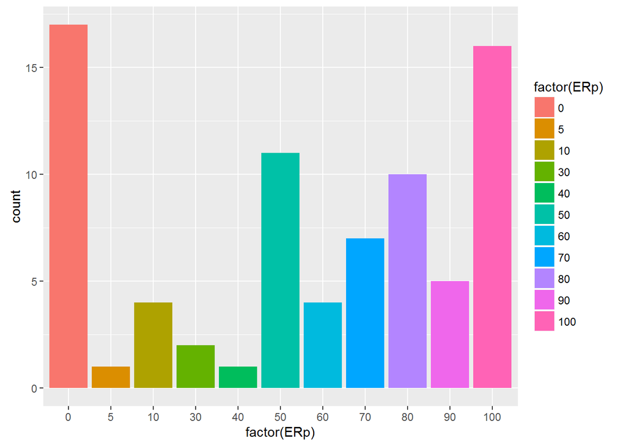

```r
qplot(factor(ERp), data=samplexprs, geom="bar", fill=factor(ERp))
```

## RMD_example 7.7: Pie chart

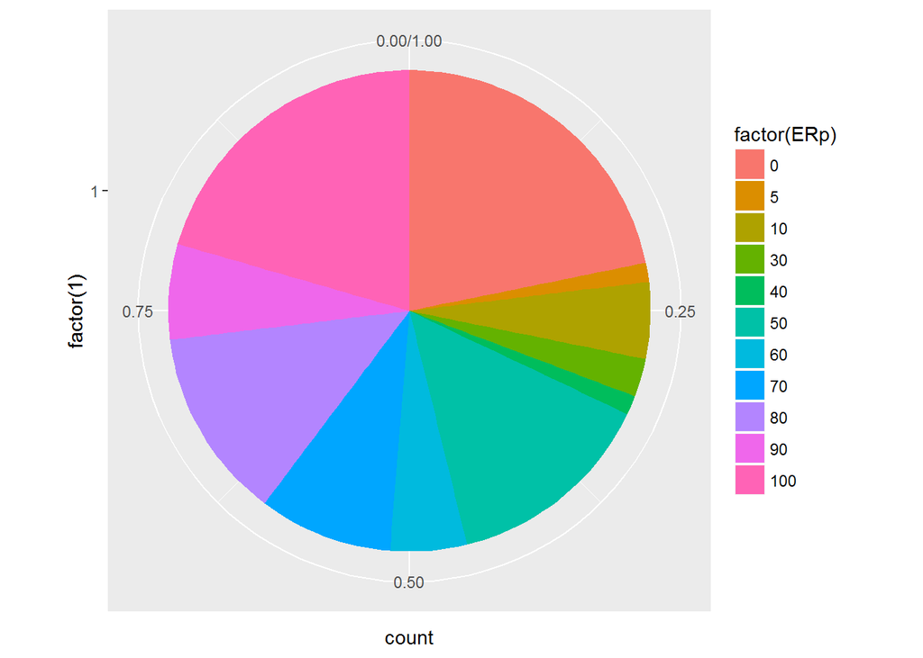

```r
p <- ggplot(samplexprs, aes(x=factor(1), fill=factor(ERp)))
p + geom_bar(width=1, position="fill") + coord_polar(theta="y")
```

## RMD_example 7.8: Scatterplot

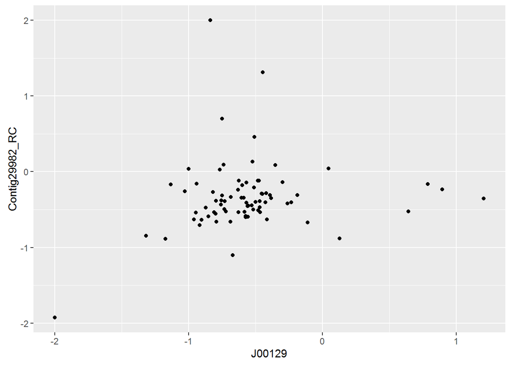

```r
s <- ggplot(samplexprs, aes(J00129, Contig29982_RC))
s + geom_point()
```

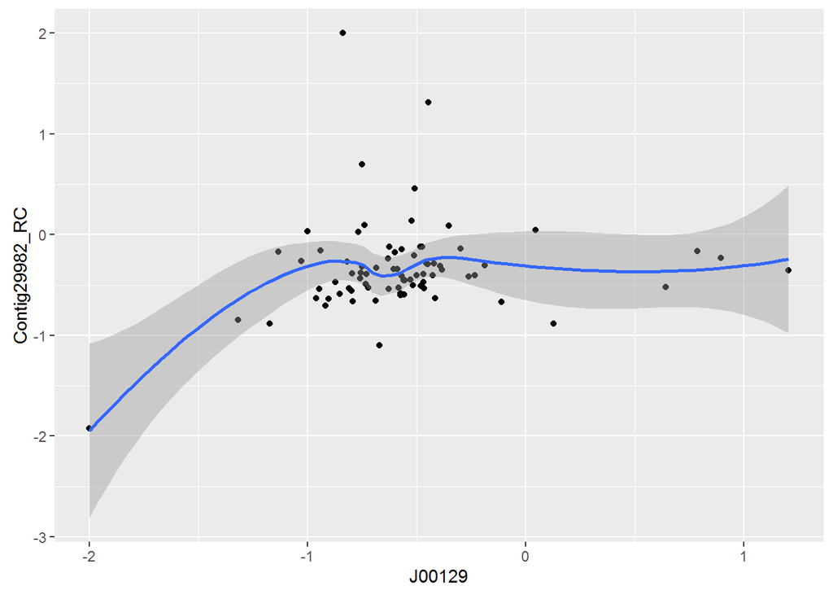

```r
# Add trend line
s + geom_point() + stat_smooth()
```

## RMD_example 7.9: Read exprs_sig.csv

```r
# Get the file url
fileurl <- "http://ghuang.stat.nctu.edu.tw/course/statmethods16/files/data/exprs_sig.csv"

# Import the csv file into R
#   note: stringsAsFactors=TRUE will screw up conversion to numeric!
exprs_sig <- read.csv(fileurl, header=TRUE, stringsAsFactors=FALSE)
#   note: read.csv treats the 1st column of exprs_sig.csv as the data, not the rownames,
#         we have to correct this
#         get the 1st column as the rownames
names1 <- exprs_sig[,1]
#         remove the 1st column from exprs_sig
exprs_sig <- exprs_sig[,-1]
#         assign the rownames
rownames(exprs_sig) <- names1
colnames(exprs_sig)
```

```
##  [1] "FG80" "SF58" "DE72" "DE65" "HG87" "HG88" "AB22" "HG91" "HG92" "KH11"
## [11] "KH20" "SF67" "LD44" "AA04" "AA01" "GL73" "AA10" "HG86" "DE62" "AB26"
## [21] "SF57" "DE61" "DD41" "AB31" "LD30" "SF66" "GL75" "AA05" "LD37" "FG78"
## [31] "DD42" "DD44" "KH99" "SF60" "DE66" "FG79" "FG83" "DD50" "DD46" "LD56"
## [41] "AA15" "AA02" "FG77" "HG93" "GL77" "HG90" "DD40" "GL71" "DD49" "LD33"
## [51] "KH15" "FG81" "DE71" "FG82" "DE73" "HG85" "LD45" "KH22" "LD35" "AA16"
## [61] "AA12" "DE63" "LD39" "DE70" "AB32" "AB20" "HG89" "SF69" "LD27" "AB24"
## [71] "AA03" "GL84" "DD43" "DD52" "FG75" "GL72" "KH14" "KH17"
```

```r
dim(exprs_sig)
```

```
## [1] 4741   78
```

```r
head(exprs_sig[,1:10])
```

```
##                  FG80   SF58   DE72   DE65   HG87   HG88   AB22   HG91
## J00129         -0.795 -0.509 -0.961 -0.749 -0.426 -0.566 -0.420 -0.499
## Contig29982_RC -0.387  0.459 -0.631  0.699 -0.406 -0.596 -0.286 -0.402
## Contig42854     0.199 -0.257  0.037 -0.346 -0.355 -0.352 -0.090  0.181
## Contig42014_RC -0.247 -0.065 -0.153  0.032  0.429 -0.336 -0.048  0.143
## Contig27915_RC  0.176  0.129  0.144  0.300 -0.036  0.037  0.291 -0.268
## Contig20156_RC -0.129  0.009 -0.202 -0.025  0.191 -0.147 -0.166  0.849
##                  HG92   KH11
## J00129         -0.465 -0.189
## Contig29982_RC -0.533 -0.309
## Contig42854    -0.019 -0.152
## Contig42014_RC  0.019  0.918
## Contig27915_RC -0.388  0.585
## Contig20156_RC -0.012 -0.144
```

## RMD_example 7.10: Scatterplot for big data

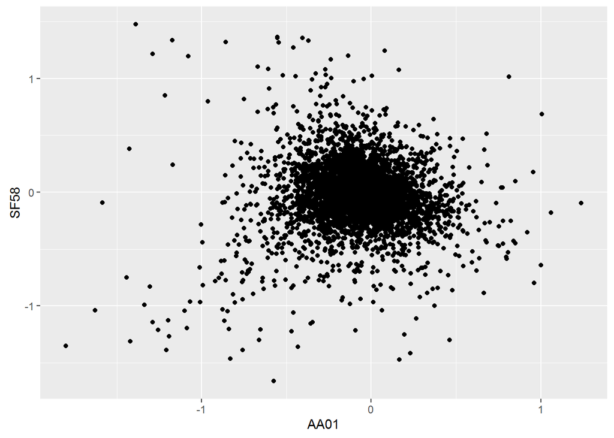

```r
sh <- ggplot(exprs_sig, aes(AA01, SF58))
sh + geom_point()
```

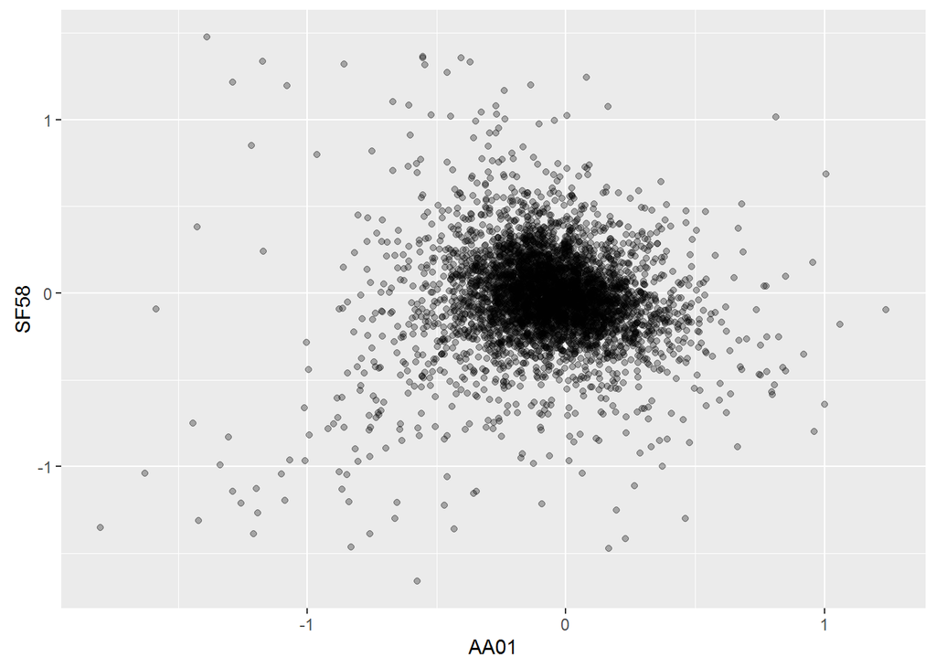

```r
# Varying alpha is useful for large datasets
sh + geom_point(alpha = 0.3)
```

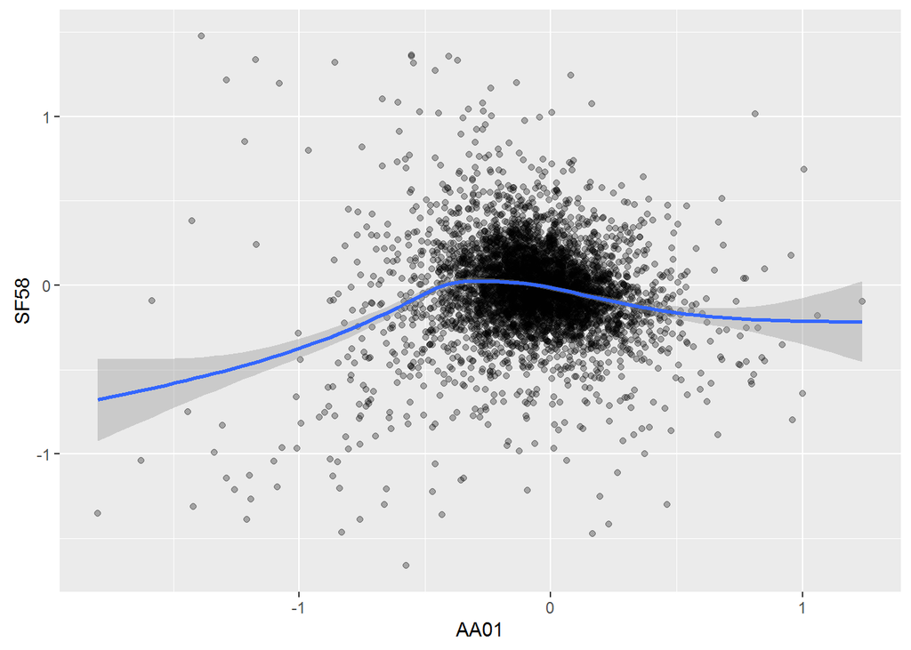

```r
# Add trend line
sh + geom_point(alpha = 0.3) + stat_smooth()
```

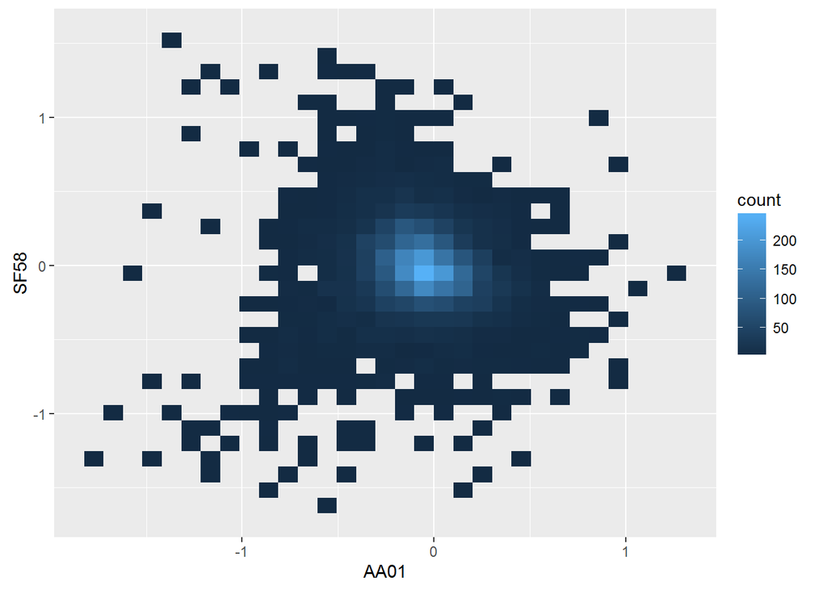

```r
# Or adding heatmap of 2d bin
sh + geom_bin2d()
```

## RMD_example 7.11: Boxplot (>1)

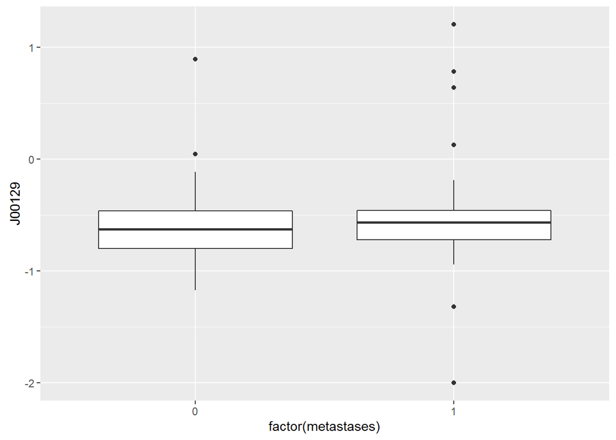

```r
# With qplot
qplot(x=factor(metastases), y=J00129, data=samplexprs, geom="boxplot")
```

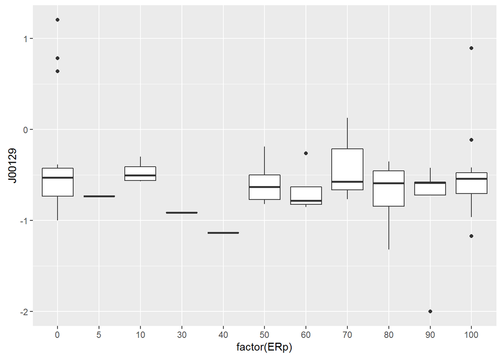

```r
qplot(x=factor(ERp), y=J00129, data=samplexprs, geom="boxplot")
```

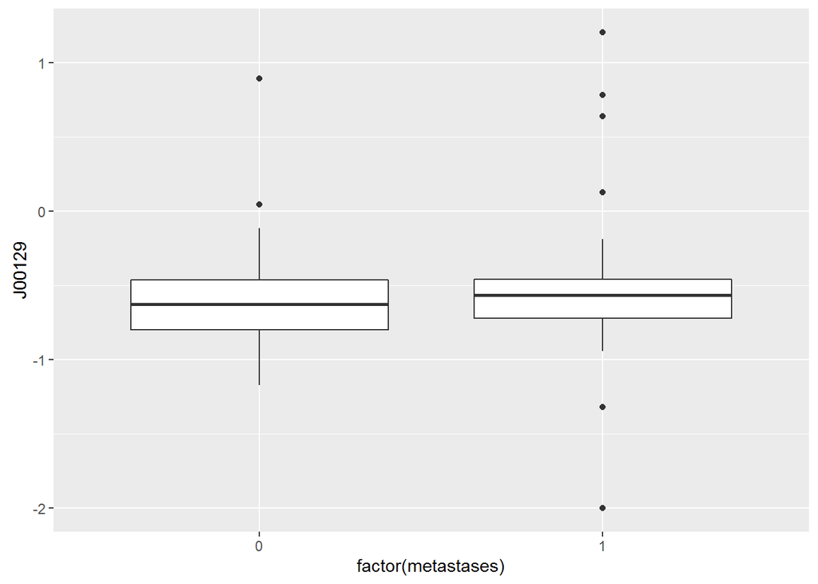

```r
# With ggplot
b2 <- ggplot(samplexprs, aes(x=factor(metastases), y=J00129))
b2 + geom_boxplot()
```

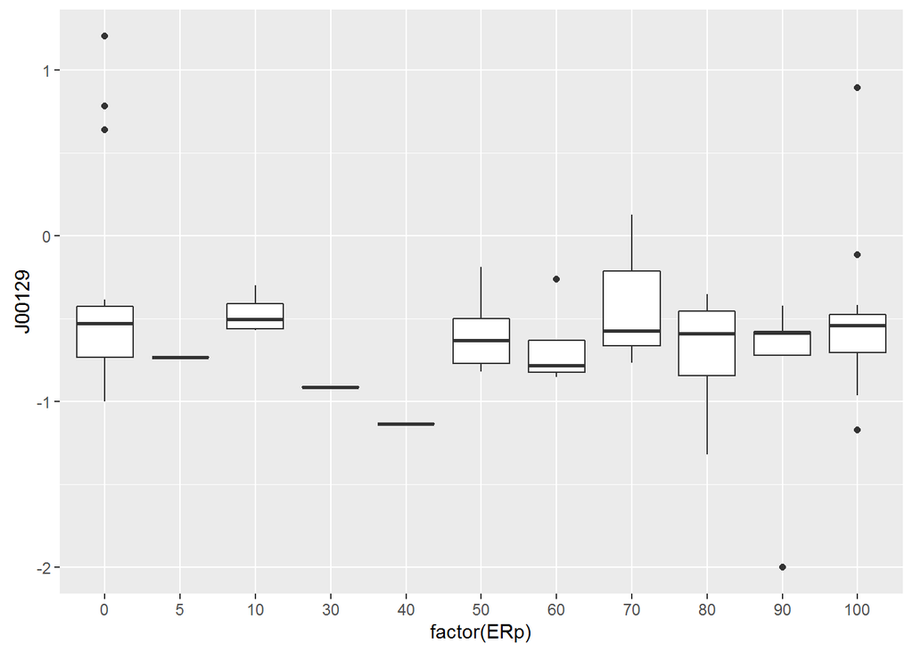

```r
b2 <- ggplot(samplexprs, aes(x=factor(ERp), y=J00129))
b2 + geom_boxplot()
```

## RMD_example 7.12: Stacked bar chart

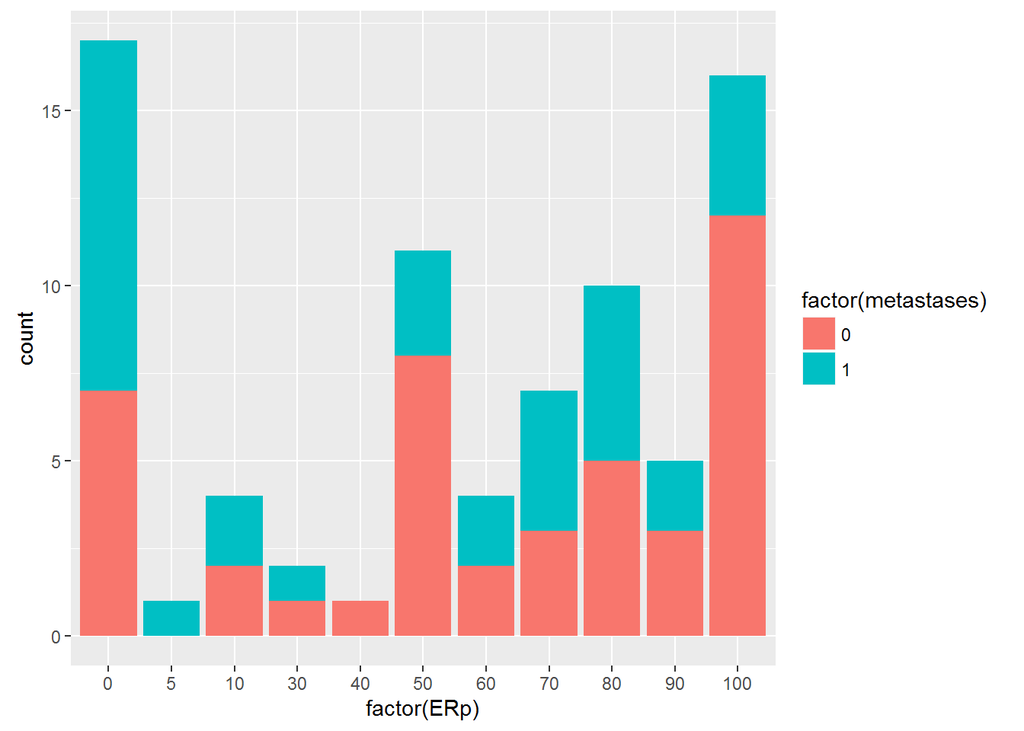

```r
sba <- ggplot(samplexprs, aes(x=factor(ERp), fill=factor(metastases)))
# y is count
sba + geom_bar()
```

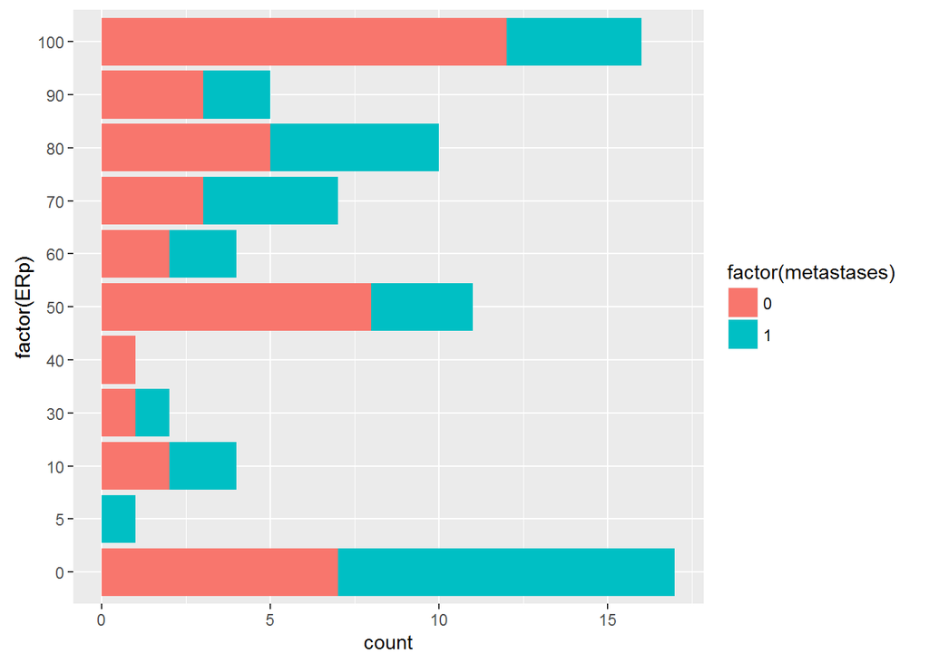

```r
sba + geom_bar() + coord_flip()
```

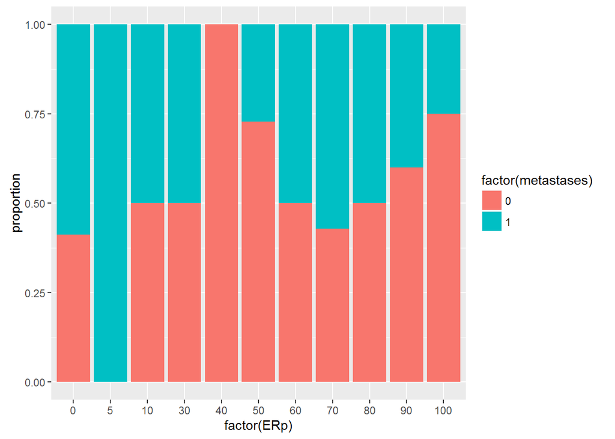

```r
# y is proportion
sba + geom_bar(position="fill") + labs(y="proportion")
```

## RMD_example 7.13: Faceting bar charts

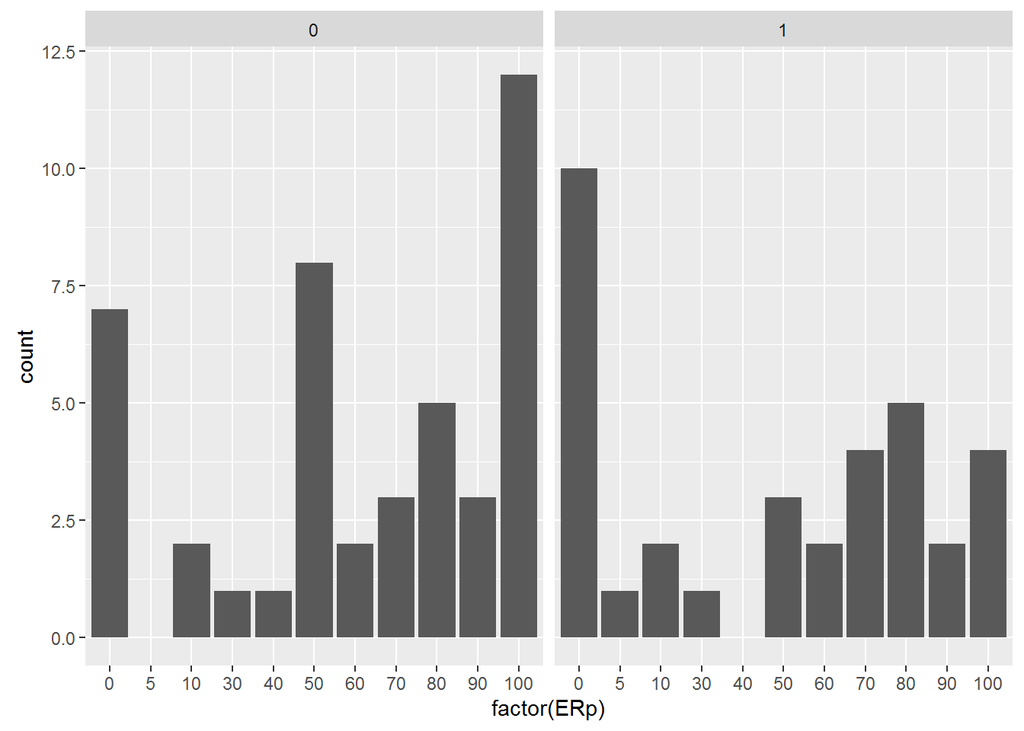

```r
fba <- ggplot(samplexprs, aes(x=factor(ERp)))
fba + geom_bar() + facet_wrap(~metastases)
```